# Analysis on data aquired

In this notebook we analyze the data parsed from all sources found in order to explain how during this COVID-19 epidemic the countries around the world have performed test to found infects.

# Target Questions

Clustr: Identificare i cluster che distinguono i vari paesi a seconda di come abbiano affrontato questa epidemia, provare a trovare una correlazione se paesi che abbiano adottato politiche simili abbiano ottenuto gli stessi risulati

```
1)Lasso di tempo
2)Test effettuati pro capite
3)Test positivi in percentuale
4)Politiche adottate
5)GDP pro capite
6)Età media
```

```python
%cd data
%run italy_data.ipynb
%run usa_data.ipynb
%run uk_data.ipynb
%run brazil_data.ipynb
%run south_korea_data.ipynb
%run indonesia_data.ipynb
%run india_data.ipynb
%run world_population.ipynb
```

```
/Users/andre/Desktop/University/Masters/Second year/Second semester/Data Science for business/Lezioni/4° Lezione - 1° Lab/datasciencebusiness/data
```

# Data used

We imported data from different country and grouped having the same columns name and arranged by date with the same structure

Those are database that we used to collect data from:

## Italy (national and regional)

### Updated: 25/04/2020

Source : https://github.com/pcm-dpc/COVID-19

## USA:

### Updated: 24/04/2020

Source : https://github.com/COVID19Tracking/covid-tracking-data

## UK:

### Updated: 29/04/2020

Source : https://github.com/tomwhite/covid-19-uk-data

## Brazil:

### Updated: 30/03/2020

Source : https://www.kaggle.com/unanimad/corona-virus-brazil

**Dataset not updated**

## SK:

### Updated: 20/04/2020

Source : https://www.kaggle.com/kimjihoo/coronavirusdataset

## Indonesia:

### Updated: 31/03/2020

Source : https://www.kaggle.com/ardisragen/indonesia-coronavirus-cases

**Dataset not updated**

## India:

### Updated: 30/04/2020

Source : https://www.kaggle.com/sudalairajkumar/covid19-in-india

More details about the columns we used for each dataset are listed in the README file.

# Sorted CSV

Structure of dataset are same for national and regional scale, below the explanation of columns:

- **total_cases:** cumulative number of infect
- **daily_cases:** daily new infect
- **actual_cases:** people actually infect
- **total_healed:** cumulative number of healed
- **daily_healed:** daily number of healed
- **total_dead:** cumulative number of dead
- **daily_dead:** daily number of dead
- **total_home_isolation:** cumulative number of people forced to home isolation
- **daily_home_isolation:** daily number of people forced to home isolation, variation between day before, can be negative
- **total_recovered_with_symptoms:** cumulative number of people recovered with symptoms
- **daily_recovered_with_symptoms:** daily number of people recovered with symptoms, variation between day before, can be negative
- **total_intensive_care:** cumulative number of people in intesive care
- **daily_intensive_care:** daily number of people in intesive care, variation between day before, can be negative
- **total_hospitalized:** cumulative number of hospitalized: simple recover + intensive care
- **daily_hospitalized:** daily number of hospitalized: simple recover + intensive care, variation between day before, can be negative
- **total_test:** cumulative number of test made
- **daily_test:** daily number of test made

Not every CSVs have all the columns listed above, due to limited data avaiable.

```python
states = ["india","italy","brazil","indonesia","south_korea","united_kingdom","usa"]

not_updated = ["brazil", "indonesia"]

states = set(states) - set(not_updated)

states = list(states)
```

```python
state_csv = {}
italian_regions_csv = {}

for state in states:
    path = os.getcwd() + "/parsed_data/"
    path += state + "/" + state + ".csv"
    path = path.replace("/",os.path.sep)
    state_csv[state] = pd.read_csv(path, index_col = 0)

path = os.getcwd() + "/parsed_data/italy/"
path = path.replace("/",os.path.sep)

all_csv = glob.glob(path + "*.csv")
all_csv.remove(path + "italy.csv")

for file in all_csv:
    result = os.path.basename(file).replace('.csv','')
    italian_regions_csv[result] = pd.read_csv(file, index_col = 0)
```

# Other data used

We collect other useful information that could help us to investigate different scenario:

- **GDP**: Data from 2018

Source: https://data.worldbank.org/indicator/NY.GDP.MKTP.CD

- **Population**
- Number of people
- Age

Source: https://population.un.org/wpp/Download/Standard/CSV/

## Import other data CSVs

```python
path_gdp = os.getcwd() + "/parsed_data/world/GDP.csv"
path_population = os.getcwd() + "/parsed_data/world/Population.csv"
path_lockdown = os.getcwd() + "/parsed_data/world/Lockdown.csv"
path_info = os.getcwd() + "/parsed_data/world/Info.csv"

path = path.replace("/",os.path.sep)

gdp = pd.read_csv(path_gdp, index_col = 0)
population = pd.read_csv(path_population, index_col = 0)
lockdown = pd.read_csv(path_lockdown, index_col = 0)
lockdown.columns = ['Country', 'Date_Start', 'Date_end_intended',
       'Description', 'Keywords']
info = pd.read_csv(path_info, index_col = 0)
```

```python
info
```

| country | political_spectrum | democracy_score | continent | GPD_pc | median_age |
| --- | --- | --- | --- | --- | --- |
| italy | centre-left | 7.52 | europe | 31586.67 | 45.5 |
| india | centre-right | 6.90 | asia | 1970.09 | 28.1 |
| south_korea | centre-left | 8.00 | asia | 34465.79 | 41.8 |
| united_kingdom | centre-right | 8.52 | europe | 42060.17 | 40.5 |
| usa | centre-right | 7.96 | america | 62067.00 | 38.1 |

### Define a lockdown meter (TODO)

Lockdown meter measures how much strict the pandemic prevention policies adopted by each state have been

```python
lockdown.columns = ['Country', 'Date_Start', 'Date_end_intended',
       'Description', 'Keywords']

unique_values = pd.unique(lockdown["Keywords"])
all_keywords = []

for row in lockdown.iterrows():
    row_keywords_found = row[1][4].split(",")
    all_keywords += row_keywords_found

dummy_all_keywords = all_keywords.copy()
all_keywords = []
meaningfull_keywords = ['closure','distancing','quarantine','remote', 'isolation', 'hospital', 'hygiene', 'medical', 'suspension']
for keyword in dummy_all_keywords:
    for meaningfull_keyword in meaningfull_keywords:
        if meaningfull_keyword in keyword.split():
            keyword = keyword.strip()
            all_keywords.append(keyword)


all_keywords = list(dict.fromkeys(all_keywords))

#len(all_keywords)

result = pd.DataFrame([(d, tup.Country,tup.Date_Start,tup.Date_end_intended) for tup in lockdown.itertuples() for d in tup.Keywords.split(", ")])
result.columns = ["keyword","country","date_start","date_end_intended"]
result.head(30)
result2 = pd.DataFrame([(tup.keyword, tup.country, tup.date_start, tup.date_end_intended) for tup in result.itertuples()if tup.keyword in all_keywords])
result2.columns = ["keyword","country","date_start","date_end_intended"]

#result2[result2["country"]=="Italy"]
```

# Plot data

## First impression

We would like to compare the number of test performed by each nation with the number of total infected people in order to find some possibile correlation between tests made nad infected founded.

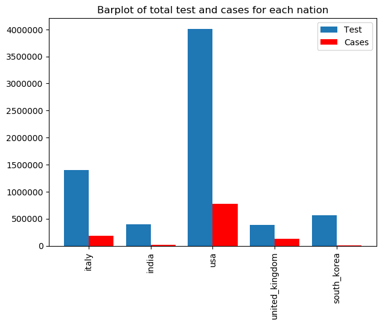

```python
fig, axes = plt.subplots(figsize=(7,5), dpi=100)

ind = np.arange(len(df.index))
plt.bar(ind-0.2, width=0.4, height=df.total_test)
plt.bar(ind+0.2, width=0.4, height=df.total_cases, color = "r")
plt.legend(["Test", "Cases"])

idx = df.index.values
idx = np.insert(idx, 0, "null") #Just to shift elements
axes.set_xticklabels(idx)

plt.setp(plt.gca().xaxis.get_majorticklabels(),rotation=90)
plt.title('Barplot of total test and cases for each nation')
```

[figure not shown]

```python
data = []
index_state = []

for state in state_csv:
    index_state.append(state)
    ix = state_csv[state].index.get_loc("2020-03-24")
    test = 100/state_csv[state].iloc[ix, state_csv[state].columns.get_loc("total_test")]
    cases = test*state_csv[state].iloc[ix, state_csv[state].columns.get_loc("total_cases")]
    temp = {"total_test":test,"total_cases":cases}
    data.append(temp)

df = pd.DataFrame(data, index = index_state, columns = ["total_test", "total_cases"])

fig, axes = plt.subplots(figsize=(7,5), dpi=100)

plt.bar(df.index, height=df.total_cases)
plt.legend(["Cases in %"])


plt.setp(plt.gca().xaxis.get_majorticklabels(),rotation=90)
plt.title('Barplot of total test and cases on 20/04/2020 in %')
```

# Some time series

### How the epidemic evoled during time

Comparison between:

- **total cases**
- **number of test**

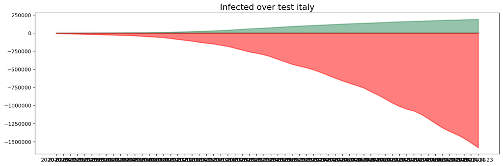

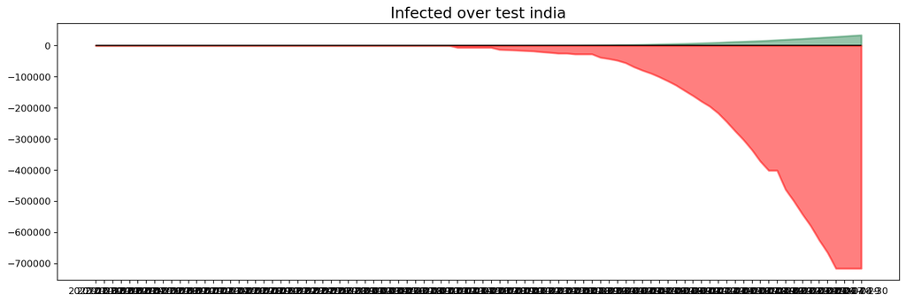

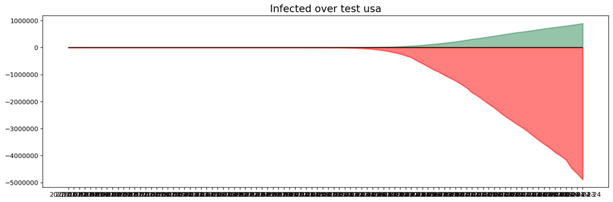

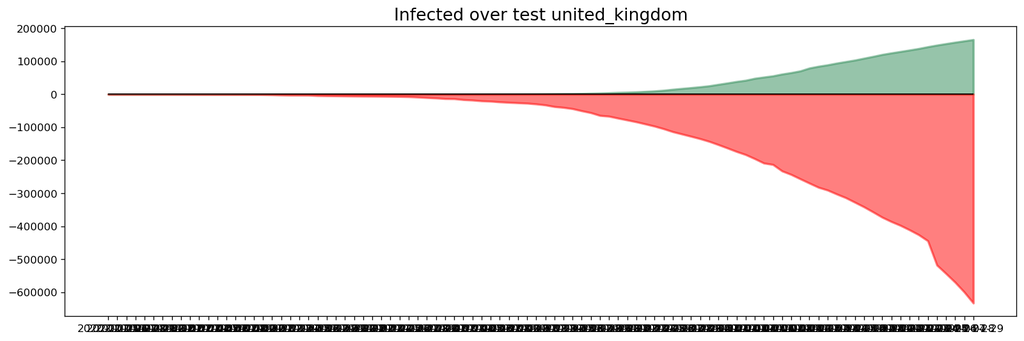

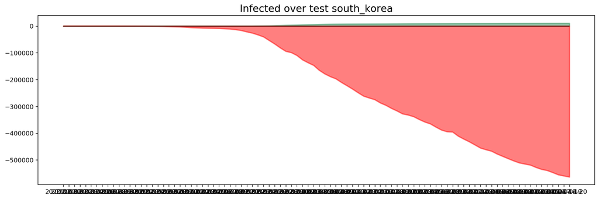

```python
for state in state_csv:
    x = state_csv[state].index
    y1 = state_csv[state].total_cases.values
    y2 = state_csv[state].total_test.values

    fig, ax = plt.subplots(1, 1, figsize=(16,5), dpi= 120)
    plt.fill_between(x, y1=y1,  alpha=0.5, linewidth=2, color='seagreen')
    plt.fill_between(x, y1=-y2, alpha=0.5, linewidth=2, color='red')
    plt.title('Infected over test ' + state, fontsize=16)
    plt.hlines(y=0, xmin=np.min(state_csv[state].index), xmax=np.max(state_csv[state].index), linewidth=1)
    plt.show()
```

# Lags analisys

- Comparison between number of test performed each week
- Compare time **t** with **t + x** for the number of test performed every week

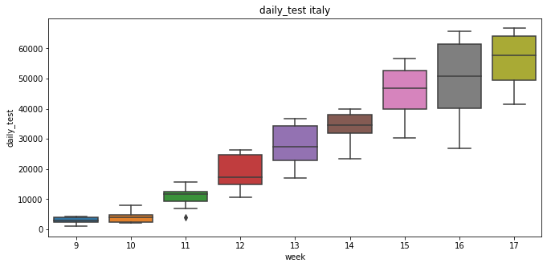

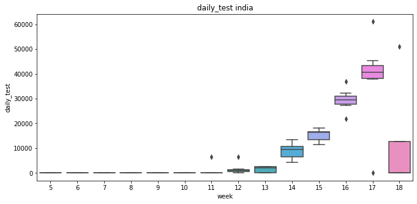

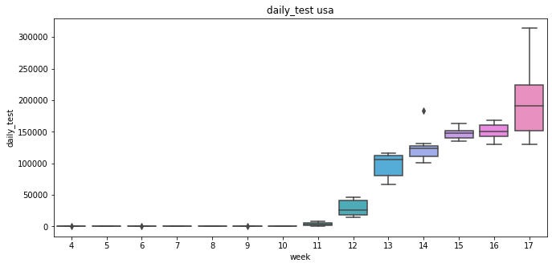

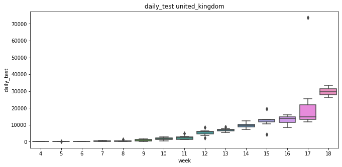

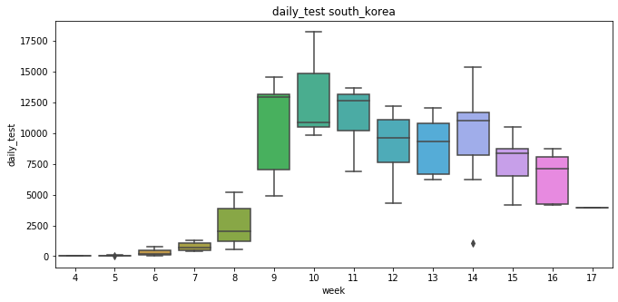

```python
for state in state_csv:
    dummystate = state_csv[state]
    newindex = pd.DatetimeIndex(dummystate.index)
    dummystate.index = newindex
    plot_interval(dummystate, state, ['daily_test'], 'week')
```

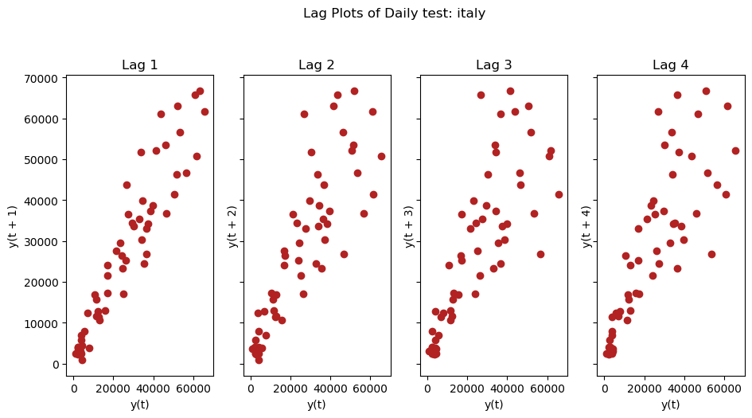

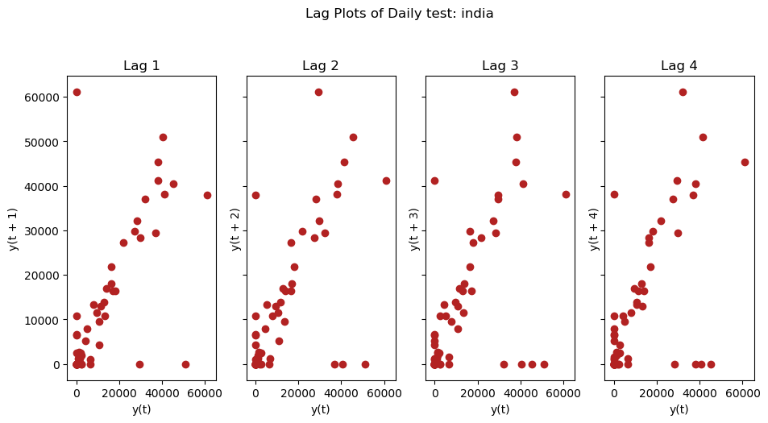

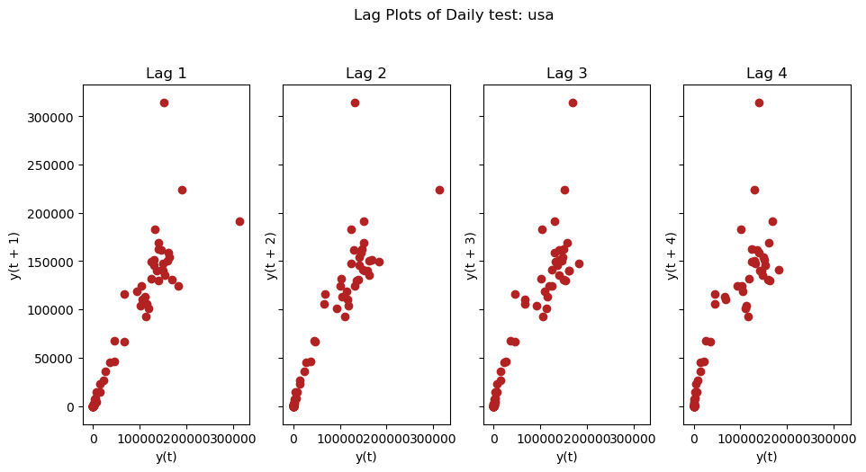

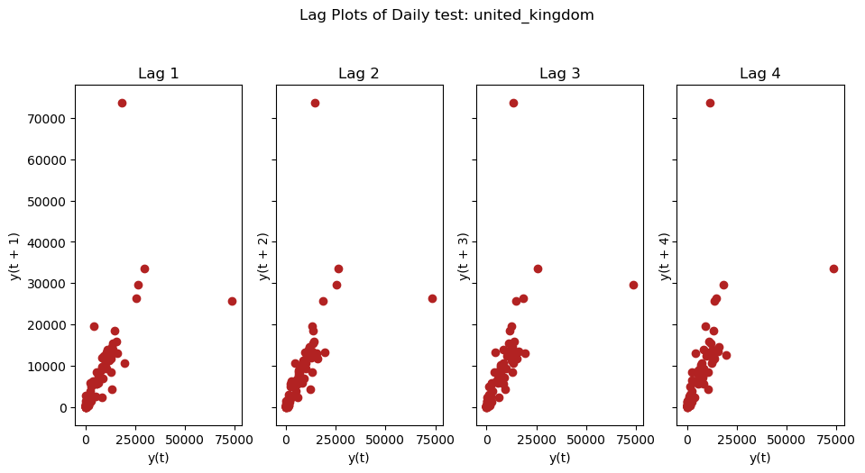

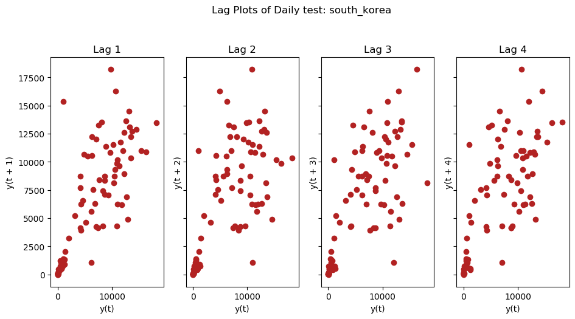

```python
from pandas.plotting import lag_plot

for state in state_csv:
    fig, axes = plt.subplots(1, 4, figsize=(11,5), sharex=True, sharey=True, dpi=100)
    for i, ax in enumerate(axes.flatten()[:4]):
        lag_plot(state_csv[state].daily_test, lag=i+1, ax=ax, c='firebrick')
        ax.set_title('Lag ' + str(i+1))

    fig.suptitle('Lag Plots of Daily test: ' + state, y=1.05)
    plt.show()
```

## Autocorrelation of daily test

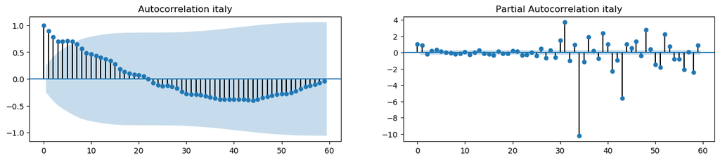

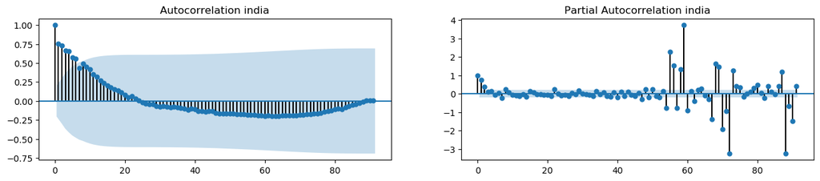

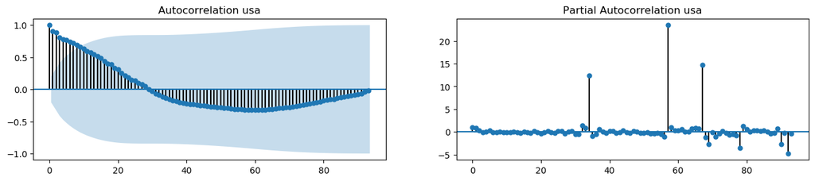

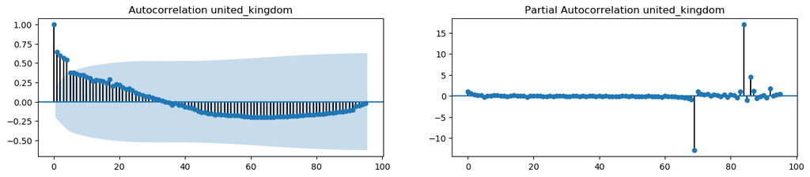

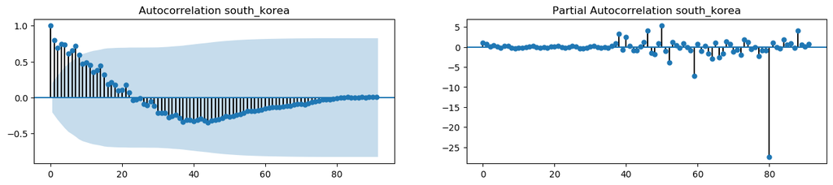

```python
from statsmodels.tsa.stattools import acf, pacf
from statsmodels.graphics.tsaplots import plot_acf, plot_pacf

for state in state_csv:
    fig, axes = plt.subplots(1,2,figsize=(16,3), dpi= 100)
    plot_acf(state_csv[state].daily_test.tolist(), lags=len(state_csv[state].index)-1, ax=axes[0], title= "Autocorrelation " + state)
    plot_pacf(state_csv[state].daily_test.tolist(), lags=len(state_csv[state].index)-1, ax=axes[1], title= "Partial Autocorrelation " + state)
```

## Stationarity analisys

```python
from statsmodels.tsa.stattools import adfuller

def test_stationarity(timeseries, state):
    """
    Check Stationariety of time series.
    Please use np.array or pd.series as Input with your TS data only
    """
    #Convert numpy array to pandas serie
    if type(timeseries) is np.ndarray:
        df_timeseries = pd.Series(timeseries)

    try:
        #Determing rolling statistics
        rolmean = df_timeseries.rolling(window=12).mean()
        rolstd = df_timeseries.rolling(window=12).std()

        #Plot rolling statistics:
        orig = plt.plot(timeseries, color='blue',label='Original')
        mean = plt.plot(rolmean, color='red', label='Rolling Mean')
        std = plt.plot(rolstd, color='black', label = 'Rolling Std')
        plt.legend(loc='best')
        plt.title('Rolling Mean & Standard Deviation of ' + state)
        plt.show(block=False)

        #Perform Dickey-Fuller test:
        print('Results of Dickey-Fuller Test:')

        dftest = adfuller(timeseries, autolag='AIC')
        dfoutput = pd.Series(dftest[0:4], index=['Test Statistic','p-value','#Lags Used','Number of Observations Used'])
        for key,value in dftest[4].items():
            dfoutput['Critical Value (%s)'%key] = value

        # print(dfoutput)

        return dftest, dfoutput
    except Exception as message:
        print(f"Impossible to calc the stationariery of your TS: {message}")
        return None, None
```

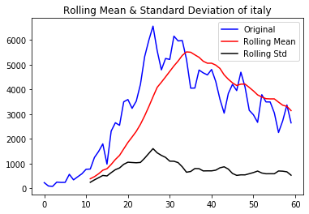

[output not shown]

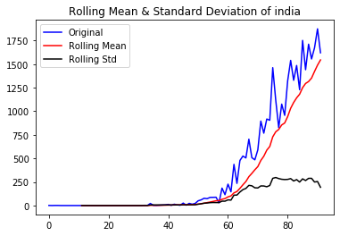

```
Results of Dickey-Fuller Test:
```

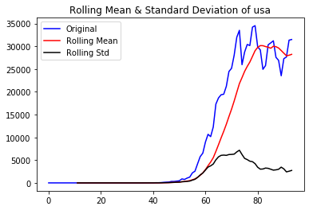

```
Results of Dickey-Fuller Test:
```

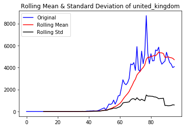

```
Results of Dickey-Fuller Test:
```

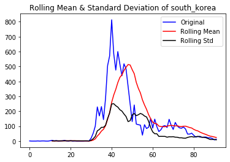

```
Results of Dickey-Fuller Test:
```

```python
for state in state_csv:
    dftest, dfoutput = test_stationarity(state_csv[state].daily_cases.values, state)
```

## Daily cases

Now that we have see the behaviour of each country about the test let's see how infected found evolved during time

### Note: Nations that didn't start a complete level of lockdown

The rapid and extensive tests taken by **South Korea** have been judged successful in limiting the spread of the outbreak, without using the drastic measure of quarantining entire cities. As of 25 February, Daegu officials were aggressively warning residents to take precautions, while allowing private businesses such as restaurants to stay open, we use that date as a started date.

```python
#Divieto spostamenti non essenziali
#Level 0 no-lockdown
#Level 1 Mass screening and isolate who has been in contact with infected
#Level 2 Max level of lockdown
level_1_of_lockdown = {"india": datetime.datetime(2020,3,22),
                     "italy": datetime.datetime(2020,2,21),
                     "indonesia": datetime.datetime(2020,3,15),
                     "south_korea": datetime.datetime(2020,2,25),
                     "united_kingdom": datetime.datetime(2020,3,16),
                     "usa":datetime.datetime(2020,3,13)} #Mean

level_2_of_lockdown = {"india": datetime.datetime(2020,3,24),
                     "italy": datetime.datetime(2020,3,9),
                     "united_kingdom": datetime.datetime(2020,3,23),
                     "usa":datetime.datetime(2020,3,20),
                     "indonesia": None,
                     "south_korea": None}
#Chiusura scuole
school_closure = {"india": datetime.datetime(2020,3,17),
                     "italy": datetime.datetime(2020,2,23),
                     "indonesia": datetime.datetime(2020,3,16),
                     "south_korea": datetime.datetime(2020,3,2),
                     "united_kingdom": datetime.datetime(2020,3,20),
                     "usa":datetime.datetime(2020,3,16)}


#INCUBATION TIME
INC_TIME = timedelta(days=15)
```

[output not shown]

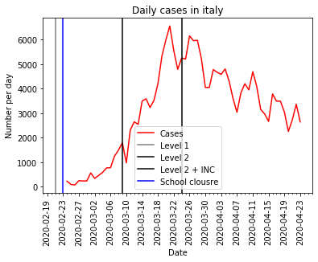

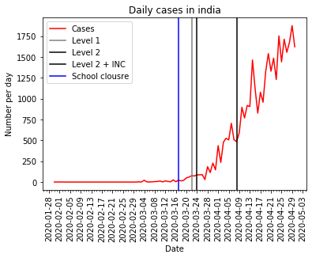

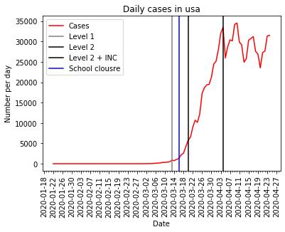

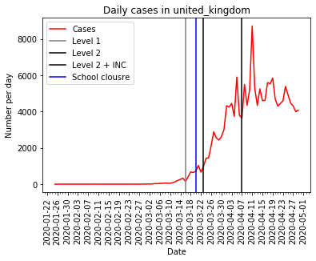

```
Not found
```

[figure not shown]

```python
import matplotlib.dates as mdates

for state in states:
    plt.title('Daily cases in ' + state)
    plt.plot(state_csv[state].index, state_csv[state].daily_cases, 'r')

    plt.axvline(level_1_of_lockdown[state], 0, 1, color = "grey")
    try:
        plt.axvline(level_2_of_lockdown[state], 0, 1, color = "k")
        plt.axvline(level_2_of_lockdown[state]+INC_TIME, 0, 1, color = "k")
    except:
        print("Not found")

    plt.axvline(school_closure[state], 0, 1, color = "blue")

    plt.setp(plt.gca().xaxis.get_majorticklabels(),rotation=90)
    plt.gca().xaxis.set_major_locator(mdates.DayLocator(interval=4))
    plt.gca().xaxis.set_minor_locator(mdates.DayLocator())

    plt.xlabel('Date')
    plt.ylabel('Number per day')
    plt.legend(["Cases", "Level 1", "Level 2", "Level 2 + INC", "School clousre"])
    plt.show()
```